# Mitochondrial ubiquitin landscape in neurons

Marek Gierlinski

15 January, 2024

Collaborators: Odetta Antico, Miratul Muqit

[Interactive data expolorer](https://shiny.compbio.dundee.ac.uk/MitoNUb)

## Data

Data came from quantitative diGlycine (diGly) capture proteomics to identify Parkin-dependent ubiquitylation. The experiment was carried out in two conditions, unstimulated/basal (UT) and stimulated/depolarised (AO) in five replicates each. The total proteome was also analysed.

There are 5,616 sites on 2,229 individual proteins in the diGly data. There are 6,255 proteins in the total proteome data.

kGG data were normalised to the total proteome, sample-to-sample. That is, UT1_ratio from kGG was divided by UT1_ratio from total proteome and so on, for all samples. kGG proteins not present in the total proteome were rejected.

## Databases

### MitoCarta

We use [MitoCarta 3.0](https://www.broadinstitute.org/files/shared/metabolism/mitocarta/human.mitocarta3.0.html) to identify mitochondrial proteins. This database contains 1,136 genes, located it the following subcompartments:

| sub_local | n | stat |
| --- | --- | --- |
| IMS | 51 | mito |
| MIM | 359 | mito |
| MOM | 110 | mito |
| MOM\|IMS | 1 | mito |
| MOM\|Matrix | 1 | mito |
| Matrix | 523 | mito |
| Matrix\|IMS | 1 | mito |
| Membrane | 34 | mito |
| unknown | 56 | mito |
| IMS | 5 | kgg |
| MIM | 45 | kgg |
| MOM | 54 | kgg |
| Matrix | 26 | kgg |
| Membrane | 9 | kgg |
| unknown | 9 | kgg |
| IMS | 4 | kgg_de |
| MIM | 26 | kgg_de |
| MOM | 43 | kgg_de |
| Matrix | 18 | kgg_de |
| Membrane | 9 | kgg_de |
| unknown | 7 | kgg_de |
| IMS | 33 | tot |
| MIM | 279 | tot |
| MOM | 86 | tot |
| MOM\|Matrix | 1 | tot |
| Matrix | 393 | tot |
| Matrix\|IMS | 1 | tot |
| Membrane | 23 | tot |
| unknown | 32 | tot |

### E2 enzymes and E3 ligases

We identify E2 and E3 using [UbiHub](https://ubihub.thesgc.org/static/UbiHub.html). We have the following numbers of enzymes and ligases in this database:

| type | n |
| --- | --- |
| DUBs USP | 57 |
| DUBs non-USP | 58 |
| E2 | 40 |
| E3 complex | 155 |
| E3 simple | 165 |

## Results

### Differential expression

Proteomics data came with Welch’s t-test p-values and fold changes. I am not sure if these are corrected for multiple tests.

Here, we re-do differential expression analysis using a more sophisticated tool, `limmma` and making sure that p-values are corrected for multiple tests. `limma` borrows information across features (sites) in order to moderate variance. We also normalise each ratio to its median. The raw data medians are close, but not equal to one, so this step reduces variance between replicates slightly and improves power of the test.

Result is not very different from the original Welch’s tests. Without the normalisation step, the numbers of significant sites (diGly) is very similar. With normalisation and using `limma`, we get 3,206 statistically significant sites. The Welch’s p-value gives 2,719 DE sites. The difference is mostly due to normalisation step.

This figure shows a volcano plot. Black points indicate data present in MitoCarta. The dashed horizontal line shows the significance limit, FDR = 0.05.

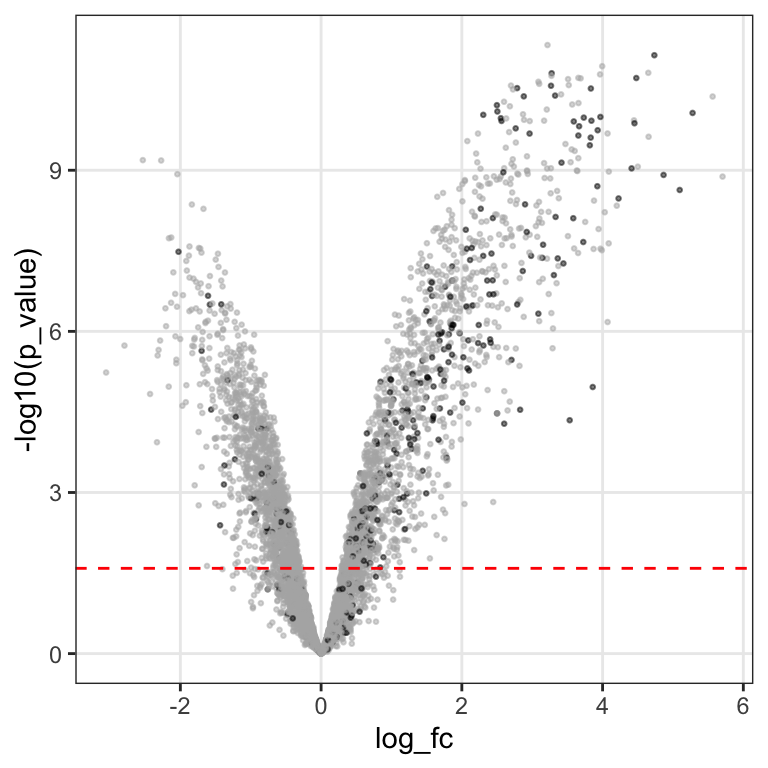

[Download data](http://www.compbio.dundee.ac.uk/user/mgierlinski/ubimito/tab/kgg_de.tsv)

### Identity of ubiquitylated proteins

We have 2,017 proteins. Out of these, there are 148 diGly proteins in MitoCarta database. None of them is E2 or E3.

This table shows the number of diGly proteins associated with each sub-compartment in MitoCarta:

| sub_local | n |
| --- | --- |
| MOM | 54 |
| MIM | 45 |
| Matrix | 26 |
| Membrane | 9 |
| unknown | 9 |
| IMS | 5 |

This figure shows distribution of counts between sub-compartments and four selection categories:

- mito - proteins in MitoCarta
- tot - proteins in total proteome
- kgg - proteins in diGly selection
- kgg_de - differentially expressed (stimulated) diGly proteins

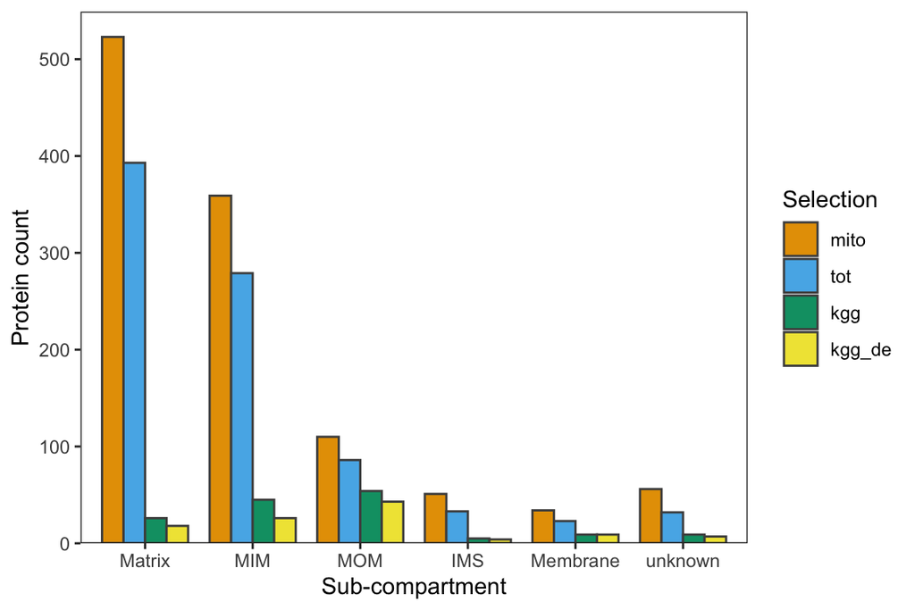

The next figure shows logFC in each compartment:

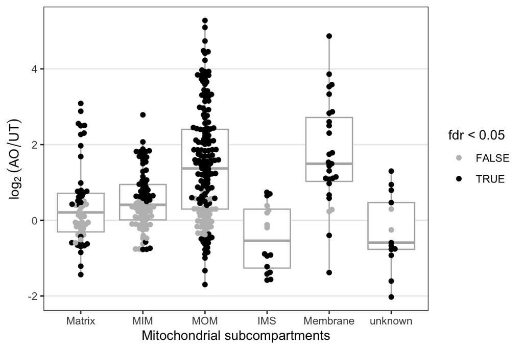

Full table with all sites:

|  | uniprot | gene_name | site_position | description | sub_local | p_value | fdr | log_fc |
| --- | --- | --- | --- | --- | --- | --- | --- | --- |
| 1 | Q9DC29 | ABCB6 | 482 | ATP-binding cassette sub-family B member 6, mitochondrial OS=Mus musculus GN=Abcb6 PE=1 SV=1 | MOM | 0.09180852916124906 | 0.1439116926658238 | 0.2922853194136797 |
| 2 | Q9DC29 | ABCB6 | 726 | ATP-binding cassette sub-family B member 6, mitochondrial OS=Mus musculus GN=Abcb6 PE=1 SV=1 | MOM | 0.00965872627943979 | 0.02180580238002339 | -0.3638711362218897 |
| 3 | Q9DC29 | ABCB6 | 771 | ATP-binding cassette sub-family B member 6, mitochondrial OS=Mus musculus GN=Abcb6 PE=1 SV=1 | MOM | 6.491351198072723e-05 | 0.0003344866458736119 | -0.8931521079295235 |
| 4 | P48410 | ABCD1 | 610 | ATP-binding cassette sub-family D member 1 OS=Mus musculus GN=Abcd1 PE=1 SV=1 | Membrane | 4.531517805652843e-05 | 0.0002463666006991669 | 1.307081006310777 |
| 5 | P48410 | ABCD1 | 696 | ATP-binding cassette sub-family D member 1 OS=Mus musculus GN=Abcd1 PE=1 SV=1 | Membrane | 7.52165521060013e-08 | 1.506593194063063e-06 | 2.865965512077806 |
| 6 | P55096 | ABCD3 | 42 | ATP-binding cassette sub-family D member 3 OS=Mus musculus GN=Abcd3 PE=1 SV=2 | Membrane | 5.236460076992426e-05 | 0.0002787198730291273 | 2.601918277349487 |
| 7 | P55096 | ABCD3 | 38 | ATP-binding cassette sub-family D member 3 OS=Mus musculus GN=Abcd3 PE=1 SV=2 | Membrane | 3.362758754442382e-05 | 0.0001951718806499892 | 2.500089007901321 |
| 8 | P55096 | ABCD3 | 50 | ATP-binding cassette sub-family D member 3 OS=Mus musculus GN=Abcd3 PE=1 SV=2 | Membrane | 2.879311205802581e-05 | 0.0001725643431329151 | 2.828494975290348 |
| 9 | P55096 | ABCD3 | 260 | ATP-binding cassette sub-family D member 3 OS=Mus musculus GN=Abcd3 PE=1 SV=2 | Membrane | 0.001310659622192372 | 0.004050576837030717 | 1.109252413416056 |
| 10 | P55096 | ABCD3 | 529 | ATP-binding cassette sub-family D member 3 OS=Mus musculus GN=Abcd3 PE=1 SV=2 | Membrane | 0.001038543634509783 | 0.003380183558135688 | 1.493943662509711 |

[output cut: 354 more lines]

[Download data](http://www.compbio.dundee.ac.uk/user/mgierlinski/ubimito/tab/kgg_mito.tsv)

### Whole proteome E2/E3

We identify following numbers of E2/E3 inside and outside of mitochondria:

| ubi_part | in_mito | n |
| --- | --- | --- |
| DUBs USP | FALSE | 24 |
| DUBs non-USP | FALSE | 29 |
| E2 | FALSE | 26 |
| E3 complex | FALSE | 38 |
| E3 simple | FALSE | 62 |
| DUBs USP | TRUE | 1 |
| E3 complex | TRUE | 1 |
| E3 simple | TRUE | 1 |

Here is a full table of these proteins.

|  | uniprot | gene_name | description | p_value | fdr | log_fc | sub_local | ubi_part | in_mito |
| --- | --- | --- | --- | --- | --- | --- | --- | --- | --- |
| 1 | Q64362 | AKTIP | AKT-interacting protein OS=Mus musculus GN=Aktip PE=1 SV=1 | 0.00476847741998431 | 0.02261321172251847 | 0.2282194342734524 |  | E2 | False |
| 2 | Q9R049 | AMFR | E3 ubiquitin-protein ligase AMFR OS=Mus musculus GN=Amfr PE=1 SV=2 | 0.001653575365840015 | 0.01153244117156649 | -0.2577320629606195 |  | E3 simple | False |
| 3 | Q9DAX9 | APPBP2 | Amyloid protein-binding protein 2 OS=Mus musculus GN=Appbp2 PE=2 SV=1 | 0.3565175500927249 | 0.4834201768545403 | 0.04349899078125254 |  | E3 complex | False |
| 4 | Q8CHG5 | AREL1 | Apoptosis-resistant E3 ubiquitin protein ligase 1 OS=Mus musculus GN=Arel1 PE=2 SV=2 | 0.07185632506311646 | 0.1482881271097966 | 0.4758314875171022 |  | E3 simple | False |
| 5 | Q9Z1K5 | ARIH1 | E3 ubiquitin-protein ligase ARIH1 OS=Mus musculus GN=Arih1 PE=1 SV=3 | 0.02619487143975969 | 0.07116879276350617 | 0.1277375516082505 |  | E3 simple | False |
| 6 | Q8BGE6 | ATG4B | Cysteine protease ATG4B OS=Mus musculus GN=Atg4b PE=1 SV=2 | 0.000125393782018945 | 0.002387341279485565 | 0.3389014598758671 |  | DUBs non-USP | False |
| 7 | Q811C2 | ATG4C | Cysteine protease ATG4C OS=Mus musculus GN=Atg4c PE=1 SV=2 | 0.1015498322412527 | 0.1924489911889562 | 0.09845126134013142 |  | DUBs non-USP | False |
| 8 | Q9CVD2 | ATXN3 | Ataxin-3 OS=Mus musculus GN=Atxn3 PE=1 SV=2 | 0.02294892430284232 | 0.06534514735328131 | 0.1227981432475598 |  | DUBs non-USP | False |
| 9 | O88738 | BIRC6 | Baculoviral IAP repeat-containing protein 6 OS=Mus musculus GN=Birc6 PE=1 SV=2 | 0.2515943489958724 | 0.375142467930675 | 0.06910748873183672 |  | E2 | False |
| 10 | P46737 | BRCC3 | Lys-63-specific deubiquitinase BRCC36 OS=Mus musculus GN=Brcc3 PE=1 SV=1 | 0.1035833347359185 | 0.1950372542965595 | 0.1620101391299592 |  | DUBs non-USP | False |

[output cut: 172 more lines]

[Download data](http://www.compbio.dundee.ac.uk/user/mgierlinski/ubimito/tab/total_mito.tsv)

### Changing sites

The next figure shows how individual sites in each protein change upon stimulation. Only diGly proteins present in MitoCarta are shown. Ubiquitylation sites are simply indexed 1, 2, 3,… from the smallest to the largest position in the protein. White fill indicates non-significant change (FDR > 0.05).

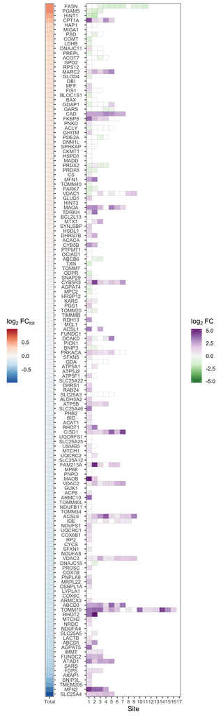

The next figure is a different visualisation of the same data. For each protein (present in MitoCarta) all sites are shown. The length of the line for each site is proportional to $|\log_2 FC|$ between UT and AO. The colour of the point indicates: red - significant positive fold change, blue - significant negative fold change, grey - non-significant change.

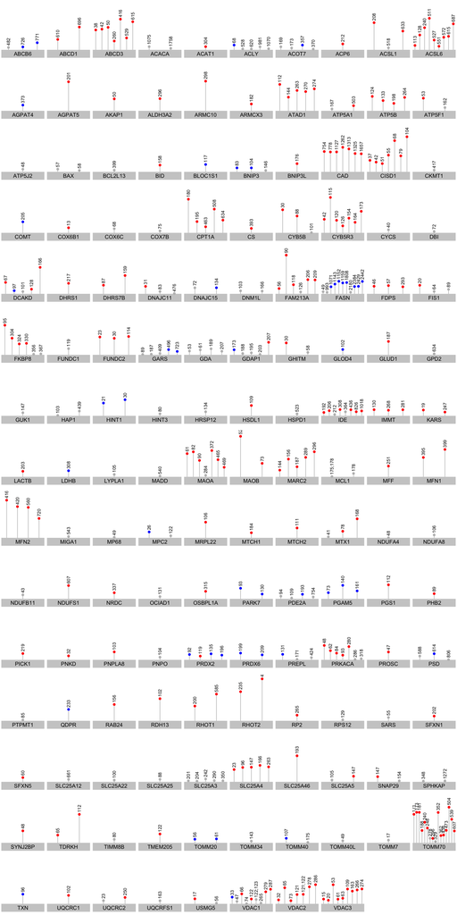